# International Day of Family Remittances - SDGs | United Nations

International Day of Family Remittances  
16 June

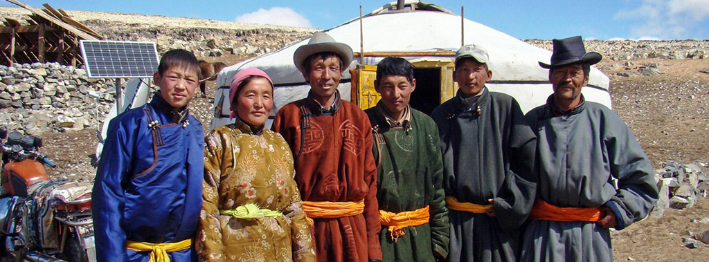

Photo: A family in rural Mongolia in front of their ger. World Bank / Erdene Orchir Barchar

## Remittances and the SDGs

### Remittances help reach the SDGs: One family at a time

Remittances can contribute to reaching the Sustainable Development Goals (SDGs) in a variety of ways:

### Remittances and SDGs report

[figure not shown]

[Download the report](http://www.un.org/sites/un2.un.org/files/2025_sdgs_brochure_e.pdf)

#### At the household level: SDGs 1-5

[figure not shown]

#### SDG 1

- Remittances represent up to 60 per cent of recipients’ families on average and typically more than double a family’s disposable income and help deal with uncertainty, allowing them to build assets.
- Analyses of 71 developing countries show significant poverty reduction effects of remittances: a 10 per cent increase in per capita remittances leads to a 3.5 per cent decline in the share of poor people in the population.

[figure not shown]

#### SDG 2

- In rural communities, half of remittances are spent on agriculture-related expenses.
- Additional income increases receiving households' demand for food, which increases domestic food production and improves nutrition, particularly among children and the elderly.
- Investment of migrants’ income in agricultural activities creates employment opportunities.

[figure not shown]

#### SDG 3

- Remittances invested in health care – access to medicine, preventive care and health insurance products – improve the health and well-being of recipient families.
- Infants born into remittance families have a higher birthweight and are less likely to die during their first year.

[figure not shown]

#### SDG 4

- One of the main reasons migrants send money home is to ensure access to better education for their children.
- Remittance-receiving households have demonstrably better educational participation than non-recipients, and invest about one tenth of their income educating their children.
- Remittances lead to almost doubling school enrolment. Children from remittance families, especially girls, register higher school attendance, enrolment rates and additional years in school.
- Remittances substantially reduce the probability of child labour participation.

[figure not shown]

#### SDG 5

- Women migrant workers now comprise half of all remittance senders: 100 million in total.
- Remittances transform the economic role of women both on the sending side and receiving end through financial independence and better employment opportunities.
- While women remit approximately the same amount as men, women tend to send a higher proportion of their income regularly and consistently, even though they generally earn less than men.

#### At the local level: SDGs 6, 7, 12 and 13

[figure not shown]

#### SDG 6

- To create social capital and pool funds to address local needs, migrants and/or their families often organize themselves into neighbourhood organizations in their communities or through Hometown Associations (HTAs) abroad.
- HTAs identify development priorities and participate in their achievement though technical advice and fund-raising.
- Projects take into account sustainability concerns and community welfare based on primary needs (e.g. the provision of irrigation and clean water infrastructure)

[figure not shown]

#### SDG 7

- Remittances have a positive impact on family assets and overall quality of life when invested in housing, and they are more likely to be used for home improvements than for home purchases.
- Affordable solutions for poor households and their communities are already available, including efficient cooking devices and clean energy solutions.
- Local community projects may apply clean energy technologies, particularly relevant in remote rural areas lacking access to electricity.

[figure not shown]

#### SDG 12

- As remittance families increase their purchase capacity and change their consumption patterns, they can do so by meeting individual needs and aspirations within the ecological limits of the planet.
- Migrant households are regular and heavy consumers of nostalgic goods (homecountry products).
- Trade of nostalgic goods and diaspora tourism imply significant revenue for countries of origin. Diaspora populations can act as a bridge to broader markets of nostalgic goods and local tourism.

[figure not shown]

#### SDG 13

- Migration is increasingly becoming a consequence of climate change. Remittances and diaspora investment play a crucial role in mitigating its negative impacts and helping cope with income shortages due to weather-related shocks.
- Remittances enable the adoption of more sustainable crops and non-farm activities. Examples include: support to local enterprises to provide solutions for flood control, more efficient use of water, improved irrigation systems, storm/heat/wind-resilient building materials, among others.

#### At the national level: SDGs 8 and 10

[figure not shown]

#### SDG 8

- Money held by remittance-receiving families and migrants’ savings in host countries improve financial resources available to the general economy. This capital can be maximized when coupled with financial and entrepreneurial services.
- Migrant workers possess tremendous assets: knowledge, skills and networks.
- In terms of development impact, migrants’ investment in micro, small or medium enterprises effectively generates employment and income in local communities.

[figure not shown]

#### SDG 10

- Reducing the cost of remittance transfers can substantially increase disposable income for remittance-receiving families.
- By reducing average costs to 3 per cent globally, remittance families would save an additional US$20 billion annually.
- Civil society awareness raising and information campaigns are achieving progress in promoting better working conditions for migrant workers.

#### At the international level: SDG 17

[figure not shown]

The international community – in line with SDG 17 – is committed to working together in order to leverage the development impact of remittances.

- Through initiatives such as the Global Compact for Safe, Orderly and Regular Migration, the international community now recognizes remittances as a vital support for hundreds of millions of people across the globe and works to strengthen their development impact on families and communities.